# Zápočtová úloha

David Napravnik

2/5/2021

# Úvod

Touto analýzou bych chtěl sledovat počet návštěv na svém webu. Web obsahuje informace o možnosti pronájmu hotelového pokoje.

# Sběr dat

Data jsem sbíral po dobu 4 a půl let. Na stránce je script od Google Analytics, který sleduje a ukládá veškerou uživatelskou aktivitu. Vygeneroval jsem si dva soubory dat, první má počet návštěv po dnech, druhý po hodinách.

Data o počtu nemocných mám ze stránky https://ourworldindata.org/coronavirus-data. Na data jsem poté aplikoval filtr, aby obsahovala jen údaje z Čr.

# Celková návštěvnost webu

Graf znázorňuje počet návštěv po dnech během sledovaného úseku ~4 let. Modrou barvou je pak vyznačena lokální regrese.

Ke konci grafu můžeme zřetelně vidět klesající regresi.

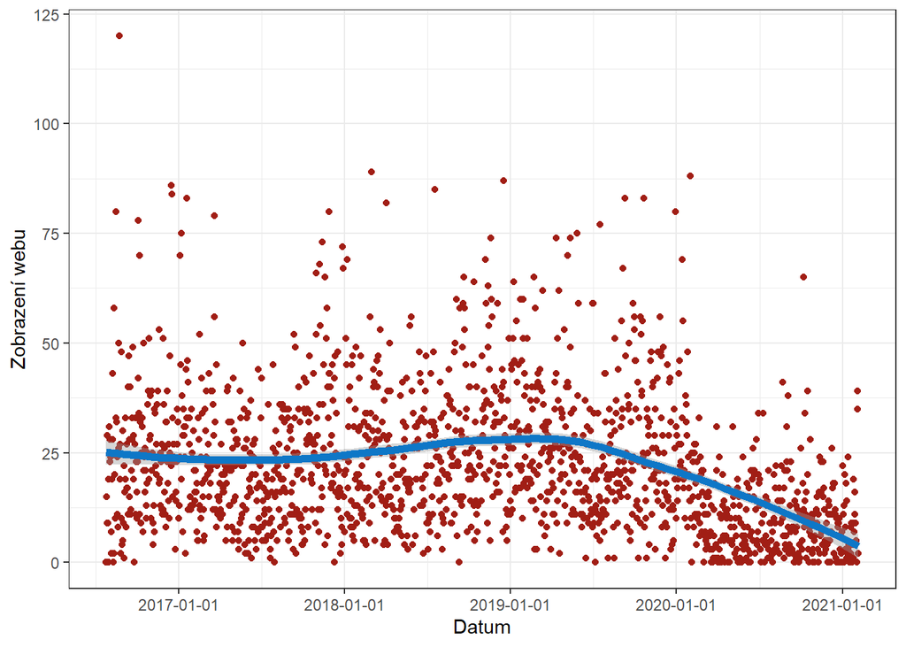

# Počet případů COIVD-19

Graf ukazuje počet případů na území Čr. Pro jednodušší porovnání se sledovaným obdobím z minulého bodu, jsou data na časové ose v poměru jako předchozí graf.

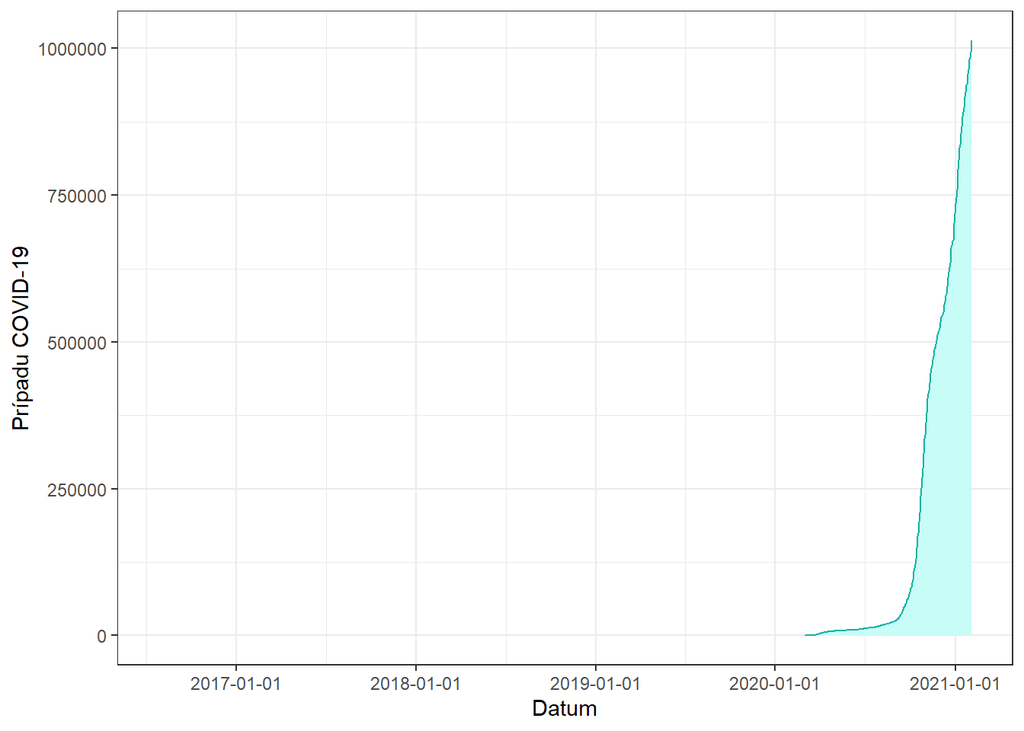

# Vliv COVID-19 na počet návštěv webu

Z prvního grafu jsme vyděli klesající počet návštěv v období výskytu covidu. Tento graf ukazuje, že pokles opravdu nastal, ale není až tak výrazný.

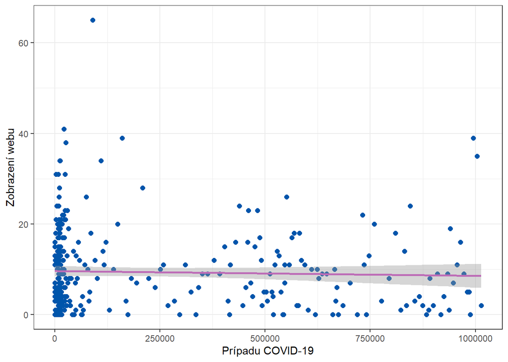

# Prohlížení webu podle dne v týdnu

Na tomto grafu vidíme, že stránky si lidé nejčastěji prohlíží ve všední dny.

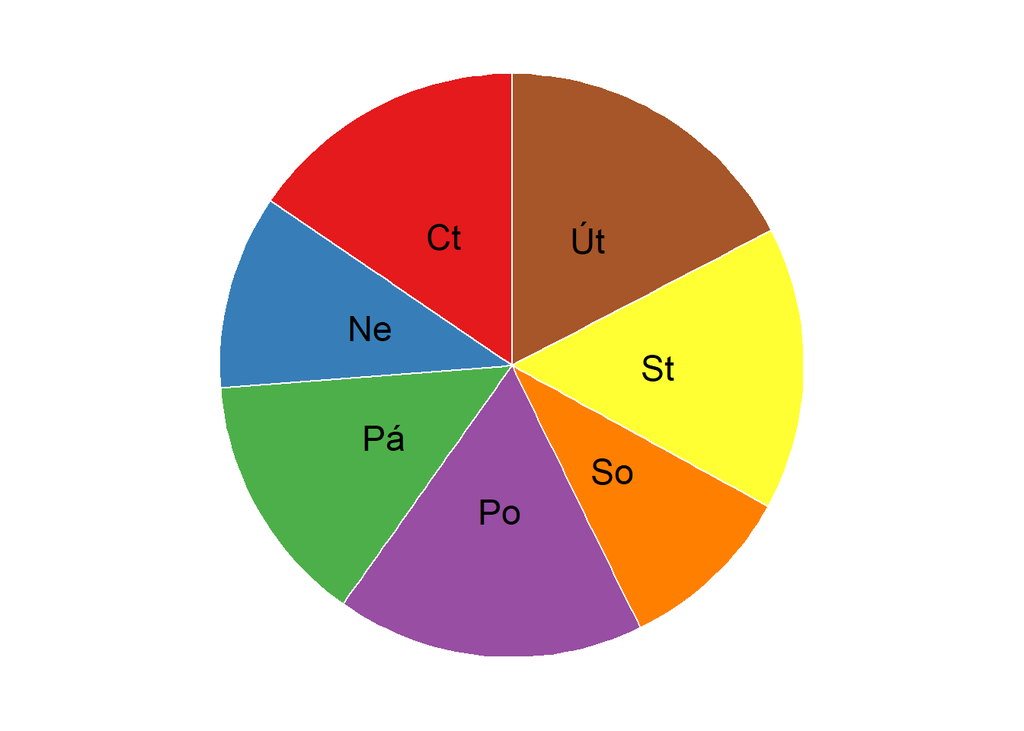

# Prohlížení webu podle denní hodiny

Z grafu vidíme, že denní doba, krom času, kdy lidé spí, je rovnoměrně rozprostřená. Vzhledem k předchozímu grafu, tedy můžeme říct, že web si lidé prohlížejí jak během pracovní doby, tak i ve svém volném čase.

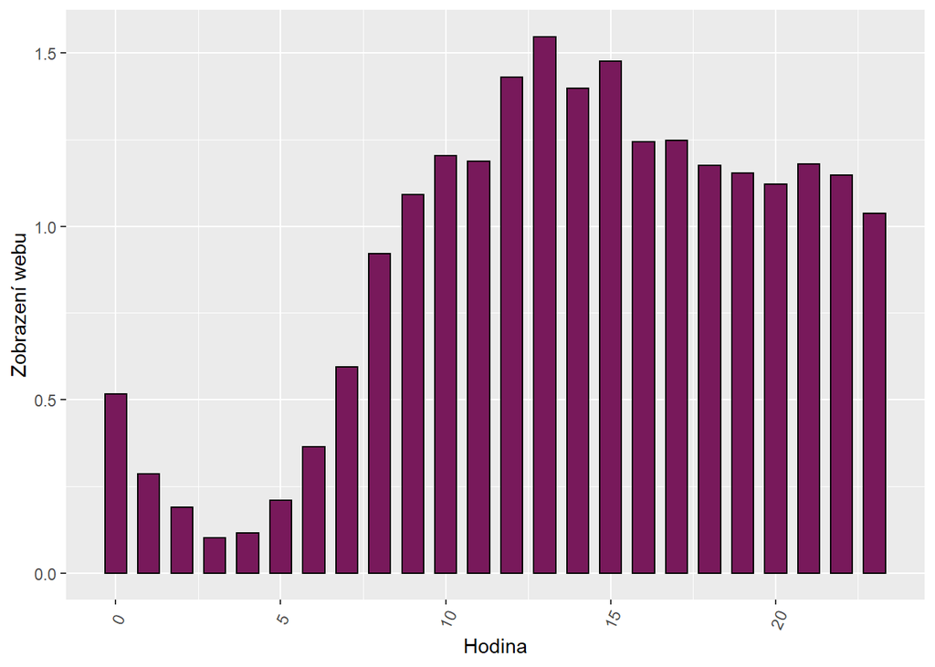

# Závěr

Touto analýzou dat, jsem sipotvrdil předpoklad, že kvůli covidu, klesl zájem o pronájem hotelového pokoje a tudíž i návštěvnost webu. Avšak pokles nebyl až tak výrazný jak jsem očekával.

# Zdroje

## Data o počtu případů COVID-19

https://ourworldindata.org/coronavirus-data

## Data o počtu zobrazení webu

https://analytics.google.com/